# Linear Programming Explaination

Vineeth Reddy.M

January 4, 2018

## Linear Programming

Linear Programming is a mathematical technique for maximizing or minimizing a linear function of several variables, such as output or cost.

Linear Programmings allows to model a large variety of situations with a simple framework.

### Real Life Usage of Linear Programming

In real world linear programming is a part of an important mathematics area called Optimization techniques.

Optimizing the operations of transportation networks to ensure the most efficient patterns of transporting goods and people,in its most basic sense finding out what trains should go where and when.

Minimizing production cost at a manufacturing facility by determining the optimal balance of production according to resources and customer demand.

Maximizing a companys’s profits by detrmining the best possible combination of activities to bring in the most money at the least cost.

Reducing risk in a potentially hazardous operation by determining the best possible combination of human and other resources.

#### Explaination of Linear Programming with an Example

Example :

A car company produces two models, model A and model B. Long-term projections indicate an expected demand of at least 100 model A cars and 80 model B cars each day. Because of limitations on production capacity, no more than 200 model A cars and 170 model B cars can be made daily. To satisfy a shipping contract, a total of at least 200 cars much be shipped each day. If each model A car sold results in a $2000 loss, but each model B car produces a $5000 profit, how many of each type should be made daily to maximize net profits?

Objective Function : The profit or cost function to be maximized or minimized is called the Objective Function.

In this case we have profit so we need to maximize it.

Profit = -2000x + 5000y

A model cars expected demand is atleast 100 cars per day

A >= 100

A model cars maximum production capacity per day is 200

A <= 200

B model cars expected demand is atleast 80 cars per day

B >= 80

B model cars maximum production capacity per day is 170

B <= 170

For satisfying the shipping contract, atleast 200 cars must be shipped every day

A + B >= 200

Based on these constraints we will find Maximum Profit and for what values of A & B we will get maximum profit using Linear Programming.

We will define different vectors for the objective function,constraints of R.H.S,directions and a matrix for constraints of L.H.S.

Mathematical Method for solving the problem:

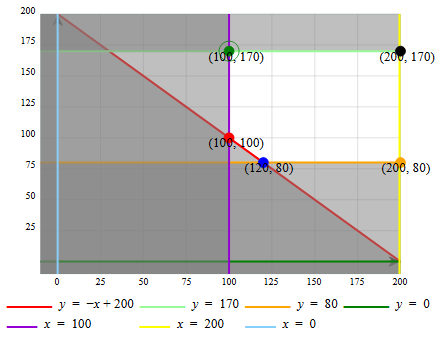

From the above graph we can infer that the white region which is in between of all the co-ordinates indicates the feasible region.

The number of cars which can be manufactured should be in that feasible region co-ordinate points.

Therefore graphically we can find out that the number of cars which can be manufactured for the maximum profit is the point with co-ordinates(100,170).

```r
library(lpSolve)

#defining parameters
#Objective Function
obj.func <- c(-2000,5000)

#Constraints on L.H.S
constr.LHS <- matrix(c(1,0,1,0,0,1,0,1,1,1),nrow=5,byrow=TRUE)

#Directions for the constraints
constr.dir <- c(">=","<=",">=","<=",">=")

#Constraints on R.H.S
constr.RHS <- c(100,200,80,170,200)

#Maximum profit which can be achieved with the given data is?
lp("max",obj.func,constr.LHS,constr.dir,constr.RHS,compute.sens=TRUE)
```

```
## Success: the objective function is 650000
```

```r
#Values of A & B to get the maximum profit is?
prod.sol <- lp("max",obj.func,constr.LHS,constr.dir,constr.RHS,compute.sens=TRUE)
prod.sol$solution
```

```
## [1] 100 170
```

Therefore we will get a maximum profit of 6,50,000 for manufacturaing 100 A model cars and 170 B model cars i.e., A=100,B=170.